# lecture4

me

6/7/2021

```r
library(tidyverse)
abreu_batted_balls <-
  read_csv("http://www.stat.cmu.edu/cmsac/sure/2021/materials/data/xy_examples/abreu_2020_batted_balls.csv")
head(abreu_batted_balls)
```

```
## # A tibble: 6 x 7
##   pitch_type batted_ball_type  hit_x hit_y exit_velocity launch_angle outcome
##   <chr>      <chr>             <dbl> <dbl>         <dbl>        <dbl> <chr>
## 1 SL         ground_ball       -8.93  56.2          88.1          -17 grounded_…
## 2 SL         line_drive       -83.8  103.          116.            16 double
## 3 FC         ground_ball       -5     57.6          72.1           -3 field_err…
## 4 FC         ground_ball      -22.4   29.7          85.2          -17 field_out
## 5 SI         ground_ball       -9.97  72.6          97.1          -19 field_out
## 6 FC         fly_ball          30.9  151.           97.9           33 field_out
```

Pitch type batted ball type outcome (categorical)

# Visualizing 1D categorical data —————–

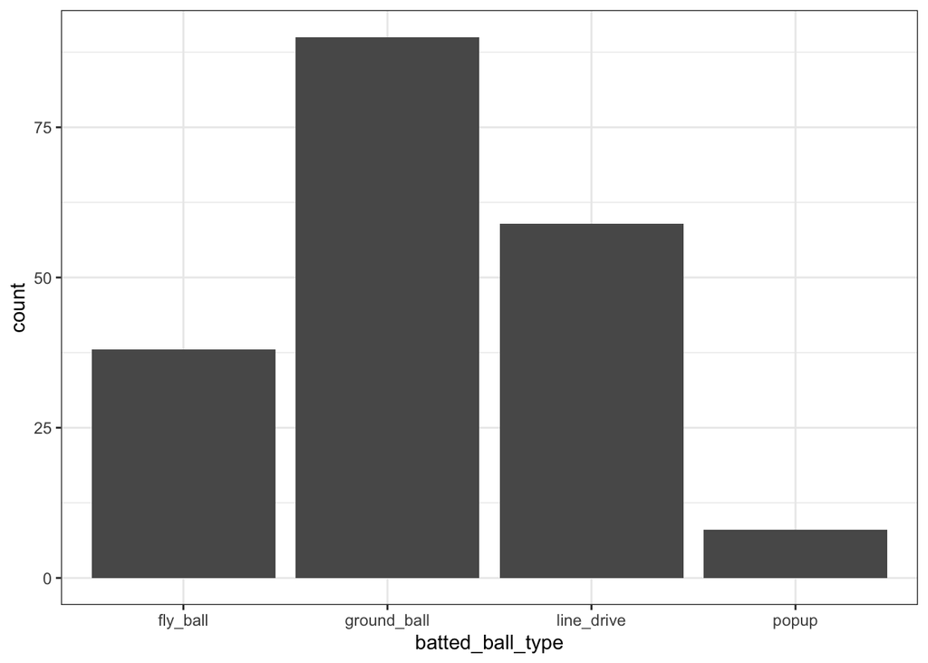

```r
abreu_batted_balls %>%
  ggplot(aes(x = batted_ball_type)) +
  geom_bar() +
  theme_bw()
```

The statistical transformation for the bar plot is the counting, it “counts” how much of each of the bar types and maps it to the y axis.

This is displaying the marginal distribution of the categorical variable.

If I want to display this as probabilities then I need to compute this seperately.

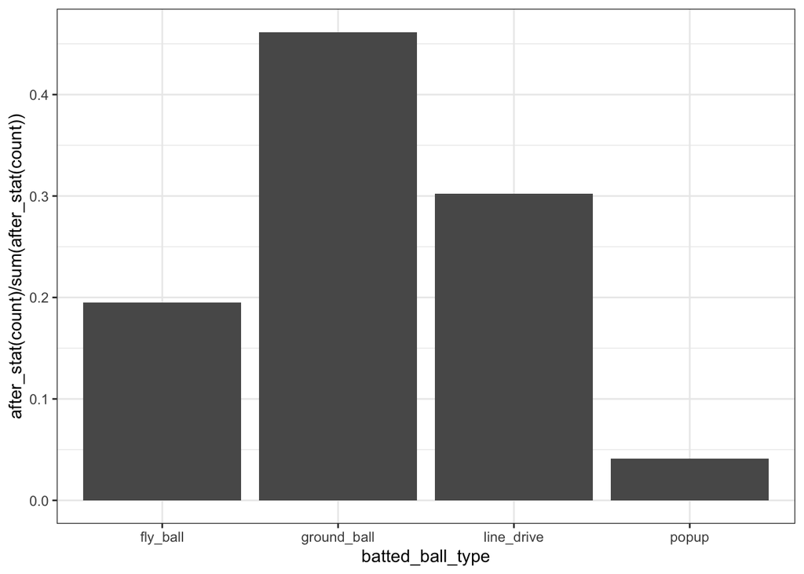

```r
abreu_batted_balls %>%
  ggplot(aes(x = batted_ball_type)) +
  geom_bar(aes(y = after_stat(count) / sum(after_stat(count)))) +
  theme_bw()
```

To do what we did above manually

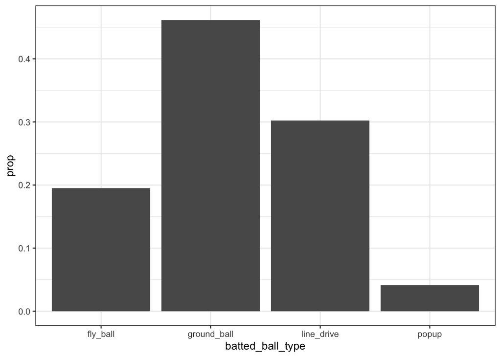

```r
abreu_batted_balls %>%
  group_by(batted_ball_type) %>%
  summarize(count = n()) %>%
  ungroup() %>%
  mutate(total = sum(count),
         prop = count / total) %>%
  ggplot(aes(x = batted_ball_type)) +
  geom_bar(aes(y = prop), stat="identity") +
  theme_bw()
```

This is the probability mass function of the probability type.

How do we compute the standard error of the sampled probability of getting a fly ball

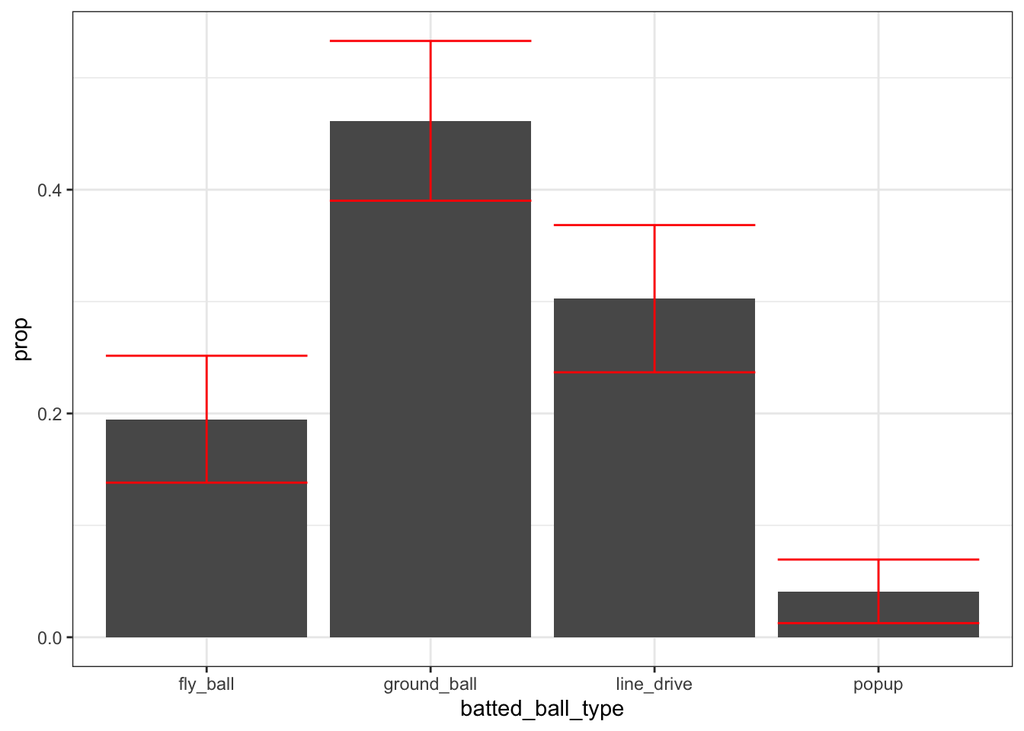

```r
abreu_batted_balls %>%
  group_by(batted_ball_type) %>%
  summarize(count = n()) %>%
  ungroup() %>%
  mutate(total = sum(count),
         prop = count / total,
         se = sqrt(prop *  (1-prop) / total),
         lower = prop - 2*se,
         upper = prop + 2*se) %>%
  ggplot(aes(x = batted_ball_type)) +
  geom_bar(aes(y = prop), stat="identity") +
  geom_errorbar(aes(ymin = lower, ymax = upper), color = "red") +
  theme_bw()
```

Interpretation of our confidence interval

If i repeated this collection of data, and the proportion of flyballs, and i kept doing this over and over and over again, and then cosntruct an CI for each sample, then 95% of the CI’s calculated will contain the true fixed parameter value.

95% of the intervals will contain the true value.

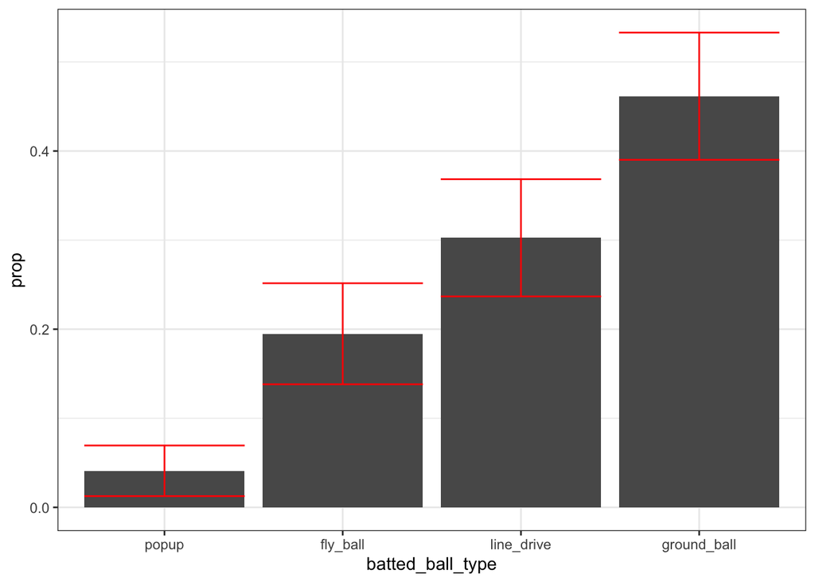

```r
abreu_batted_balls %>%
  group_by(batted_ball_type) %>%
  summarize(count = n()) %>%
  ungroup() %>%
  mutate(total = sum(count),
         prop = count / total,
         se = sqrt(prop *  (1-prop) / total),
         lower = prop - 2*se,
         upper = prop + 2*se,
         batted_ball_type = fct_reorder(batted_ball_type, prop)) %>%
  ggplot(aes(x = batted_ball_type)) +
  geom_bar(aes(y = prop), stat="identity") +
  geom_errorbar(aes(ymin = lower, ymax = upper), color = "red") +
  theme_bw()
```

# Continuous Variables ———

Center: mean, median, number, and location of modes Spread : range(max-min), quantiles, variance (std), etc Shape : skew vs symmetry, outliers

```r
summary(abreu_batted_balls$exit_velocity)
```

```
##    Min. 1st Qu.  Median    Mean 3rd Qu.    Max.
##   29.10   85.20   97.50   93.15  104.50  115.60
```

```r
sd(abreu_batted_balls$exit_velocity)
```

```
## [1] 14.30565
```

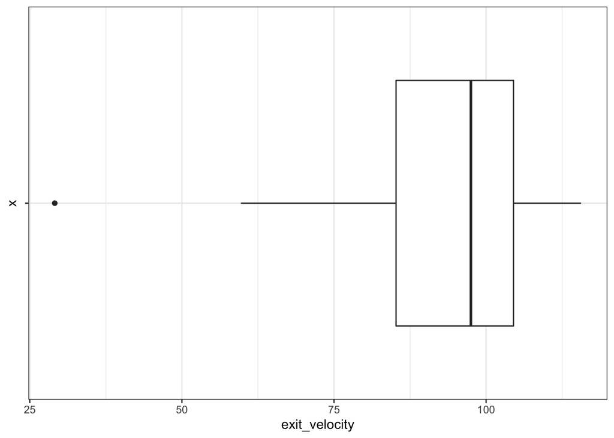

```r
abreu_batted_balls %>%
  ggplot(aes(y = exit_velocity)) +
  geom_boxplot(aes(x = "")) +
  theme_bw()+
  coord_flip()
```

Boxplots are limited in that we don’t know how many modes there are in the dataset.

It can be helpful but not all that useful in itself.

# histogram ———

Taking a variable Binning it Counting it

It is an attempt of density estimation. Finding some way of smoothing data of a continuous variable.

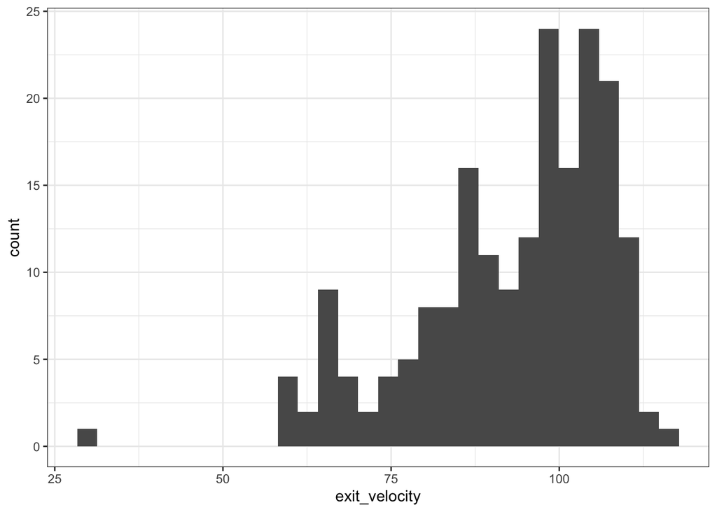

```r
abreu_batted_balls %>%
  ggplot(aes(x = exit_velocity)) +
  geom_histogram() +
  theme_bw()
```

The box plots give me no sense of peaks in this histogram.

Within a particular range of values I’ve received the count for the certain amount of balls.

Histograms are something you have to tune. You are choosing a statistical transformation

How do I normalize it?

# Another way to display continuous distributions ———–

```r
library(ggbeeswarm)
```

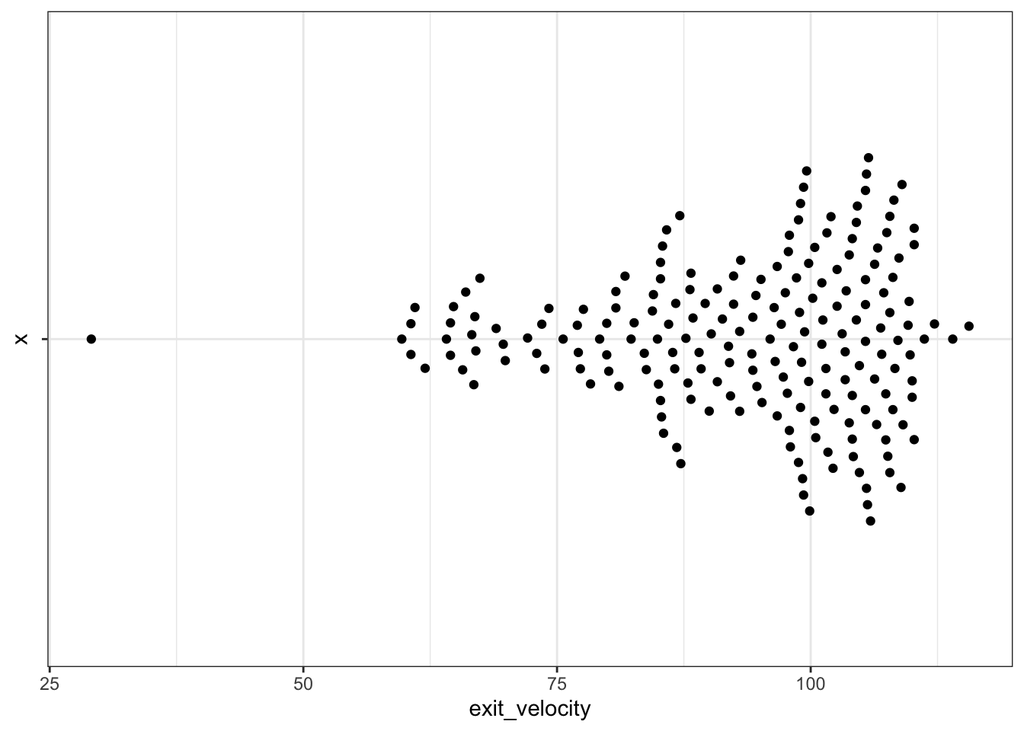

```r
abreu_batted_balls %>%
  ggplot(aes(y = exit_velocity)) +
  geom_beeswarm(aes(x = ""),  cex = 3) +
  theme_bw() +
  coord_flip()
```

# Violin Plot ——-

Another display that works well with other displays is violin plots

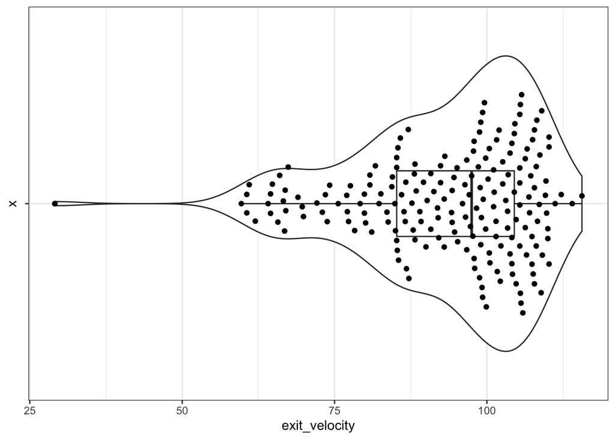

```r
abreu_batted_balls %>%
  ggplot(aes(y = exit_velocity, x = "")) +
  geom_violin() +
  geom_boxplot(width = .2) +
  geom_beeswarm(aes(x = ""),  cex = 3) +
  theme_bw() +
  coord_flip()
```

# ECDF —–

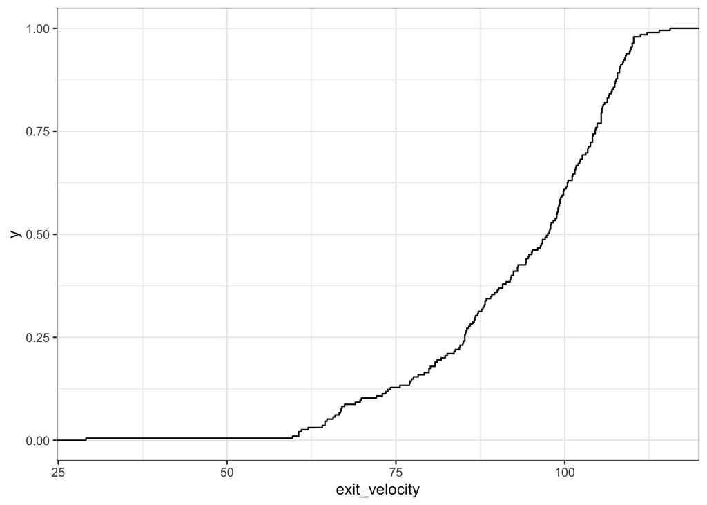

```r
abreu_batted_balls %>%
   ggplot(aes(x = exit_velocity)) +
  stat_ecdf() +
  theme_bw()
```